# R Notebook

# KNN

Kutuphaneler

```r
#Classification And REgression Training
install.packages("FNN")
library(caret)
library(tidyverse)
library(AppliedPredictiveModeling)
library(pls) #kismi en kucuk kareler ve pcr icin
library(elasticnet)
library(broom) #tidy model icin
library(glmnet)
library(MASS)
library(ISLR)
library(PerformanceAnalytics)
library(funModeling)
library(Matrix)
library(kernlab) #svm
library(e1071) #svm icin
library(rpart) #cart icin
library(pgmm) #olive data seti icin
library(dslabs)
library(rpart.plot) #rpart gorsel icin
library(partykit) #karar agaci gorseli icin
library(ipred) #bagging icin
library(randomForest)
library(gbm)
library(nnet)
library(neuralnet)
library(GGally)
library(NeuralNetTools) #garson fonksiyonu icin
library(FNN)
```

## Veri Seti

```r
df <- Hitters
# eksik veri olan kayıtları sildik
df <- na.omit(df)
# "League","NewLeague","Division" değişkenlerini verisetinden kaldırdık
df <- df %>% dplyr::select(-c("League","NewLeague","Division"))
rownames(df) <- c()
set.seed(3456)
train_indeks <- createDataPartition(df$Salary,
                                    p = .8,
                                    list = FALSE,
                                    times = 1)
head(train_indeks)
```

```
     Resample1
[1,]         2
[2,]         4
[3,]         5
[4,]         6
[5,]         7
[6,]         8
```

```r
train <- df[train_indeks, ]
test <- df[-train_indeks, ]
train_x <- train %>% dplyr::select(-Salary)
train_y <- train$Salary
test_x <- test %>% dplyr::select(-Salary)
test_y <- test$Salary
#tek bir veri seti
training <- data.frame(train_x, Salary = train_y)
```

## Model

```r
head(knn_fit$pred)
```

```
[1] 593.7500 718.7500 546.6665  95.0000 177.5000  95.0000
```

```r
head(test_y)
```

```
[1] 475 500 775 175 110  90
```

## Tahmin

```r
defaultSummary(data.frame(obs = test_y, pred = knn_fit$pred))
```

```
       RMSE    Rsquared         MAE
290.0854607   0.4276074 184.9280882
```

## Model Tuning

```r
defaultSummary(data.frame(obs = test_y,
pred = predict(knn_tune, test_x)))
```

```
       RMSE    Rsquared         MAE
257.7089997   0.5535398 184.2919529
```

# SVR

## Model

```r
names(svm_fit)
```

```
 [1] "call"            "type"            "kernel"          "cost"            "degree"
 [6] "gamma"           "coef0"           "nu"              "epsilon"         "sparse"
[11] "scaled"          "x.scale"         "y.scale"         "nclasses"        "levels"
[16] "tot.nSV"         "nSV"             "labels"          "SV"              "index"
[21] "rho"             "compprob"        "probA"           "probB"           "sigma"
[26] "coefs"           "na.action"       "fitted"          "decision.values" "residuals"
```

## Tahmin

```r
head(predict(svm_fit, test_x))
```

```
        1         3        15        16        27        31
 550.0140 1095.3835  974.9394  227.3848  120.9306  121.1530
```

```r
head(test_y)
```

```
[1] 475 500 775 175 110  90
```

## Model Tunning

```r
defaultSummary(data.frame(obs = test_y,
pred = predict(svm_tune, test_x)))
```

```
       RMSE    Rsquared         MAE
243.8261278   0.6085985 170.5772708
```

# YSA

## Veri Seti ve Hazirlik

Yat hidrodinamigine ait veri seti.

http://archive.ics.uci.edu/ml/datasets/Yacht+Hydrodynamics

```r
dff <- read_table(file = 'http://archive.ics.uci.edu/ml/machine-learning-databases/00243/yacht_hydrodynamics.data',
col_names = c('longpos_cob',
              'prismatic_coeff',
              'len_disp_ratio',
              'beam_draut_ratio',
              'length_beam_ratio',
              'froude_num',
              'residuary_resist'))
```

Veri Setine Goz Atmak

```r
glimpse(dff)
profiling_num(dff)
ggpairs(dff)
mean(dff$residuary_resist)
```

```r
# yapay sinir ağlarını kullanmadan önce içerisinde kullanılacak değişkenler ölçeklendirilir
olcek <- function(x) {

  (x-min(x)) / (max(x) - min(x))

}
df <- na.omit(dff)
# ölçekleme uygulandı
df <- df %>% mutate_all(olcek)
set.seed(3456)
train_indeks <- createDataPartition(df$residuary_resist,
                                  p = .8,
                                  list = FALSE,
                                  times = 1)
train <- df[train_indeks,]
test  <- df[-train_indeks,]
train_x <- train %>% dplyr::select(-residuary_resist)
train_y <- train$residuary_resist
test_x <- test %>% dplyr::select(-residuary_resist)
test_y <- test$residuary_resist
#tek bir veri seti
training <- data.frame(train_x, residuary_resist = train_y)
df
```

| longpos_cob | prismatic_coeff | len_disp_ratio | beam_draut_ratio | length_beam_ratio | froude_num | residuary_resist |
| --- | --- | --- | --- | --- | --- | --- |
| 0.54 | 0.5428571 | 0.5500 | 0.46456693 | 0.48351648 | 0.00000000 | 0.0016023073 |
| 0.54 | 0.5428571 | 0.5500 | 0.46456693 | 0.48351648 | 0.07692308 | 0.0041659990 |
| 0.54 | 0.5428571 | 0.5500 | 0.46456693 | 0.48351648 | 0.15384615 | 0.0073706137 |
| 0.54 | 0.5428571 | 0.5500 | 0.46456693 | 0.48351648 | 0.23076923 | 0.0123377664 |
| 0.54 | 0.5428571 | 0.5500 | 0.46456693 | 0.48351648 | 0.30769231 | 0.0187469957 |
| 0.54 | 0.5428571 | 0.5500 | 0.46456693 | 0.48351648 | 0.38461538 | 0.0290017625 |
| 0.54 | 0.5428571 | 0.5500 | 0.46456693 | 0.48351648 | 0.46153846 | 0.0416599904 |
| 0.54 | 0.5428571 | 0.5500 | 0.46456693 | 0.48351648 | 0.53846154 | 0.0600865246 |
| 0.54 | 0.5428571 | 0.5500 | 0.46456693 | 0.48351648 | 0.61538462 | 0.0797949047 |
| 0.54 | 0.5428571 | 0.5500 | 0.46456693 | 0.48351648 | 0.69230769 | 0.1145649736 |

[output cut: 298 more lines]

## Model

1 Katmanli 1 Norunlu Basit Yapay Sinir Hucresi

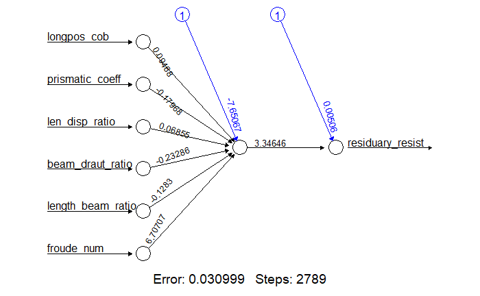

```r
#model formulu
ysa_formul <- residuary_resist ~ longpos_cob + prismatic_coeff + len_disp_ratio + beam_draut_ratio + length_beam_ratio + froude_num
ysa1 <- neuralnet(ysa_formul, data = training)
plot(ysa1)
```

```r
ysa1$result.matrix
```

```
                                       [,1]
error                          3.099886e-02
reached.threshold              9.844303e-03
steps                          2.789000e+03
Intercept.to.1layhid1         -7.650665e+00
longpos_cob.to.1layhid1        9.467935e-02
prismatic_coeff.to.1layhid1   -1.796777e-01
len_disp_ratio.to.1layhid1     6.854932e-02
beam_draut_ratio.to.1layhid1  -2.328563e-01
length_beam_ratio.to.1layhid1 -1.282993e-01
froude_num.to.1layhid1         6.707067e+00
Intercept.to.residuary_resist  5.062303e-03
1layhid1.to.residuary_resist   3.346462e+00
```

Katman ve Noron Sayisinin Arttirilmasi

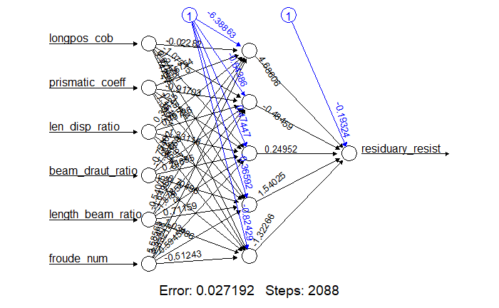

```r
# hidden = 5 5 sinirli bir gizli katman oluşturuldu
# hidden = c(5,1,2)
plot(neuralnet(ysa_formul, data = training,
               hidden = 5),rep =  "best")
```

```r
ysa2 <- neuralnet(ysa_formul, data = training,
               hidden = 5)
ysa3 <- neuralnet(ysa_formul, data = training,
               hidden = c(3,2))
```

## Degisken Onem ve Etki Duzeyleri

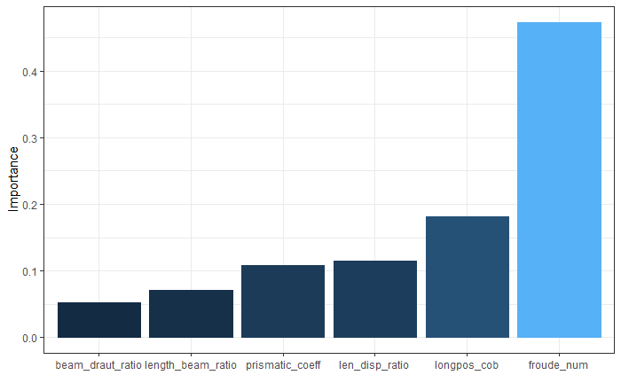

```r
# bağımsız değişkenlerin etki düzeylerini değerlendirmek için kullanılan iki metod
# quartile ( çeyreklik ) 'lar ile bağımsız değişkenlerin bağımlı değişken üzerindeki etkisini ölçer
garson(ysa2)
```

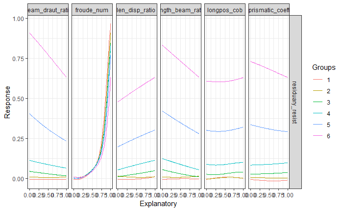

```r
lekprofile(ysa2)
```

olceklendirmeyi Geri Almak

```r
# ysa ile bir model oluşturmak için verileri standartlaştırmıştık fakat verileri bu model ile tahmin ederken standartlaştırılmış verileri normal haline çevirmek gerekmektedir
# bunun için atamaları yeniden yaptık
dff <- read_table(file = 'http://archive.ics.uci.edu/ml/machine-learning-databases/00243/yacht_hydrodynamics.data',
col_names = c('longpos_cob',
              'prismatic_coeff',
              'len_disp_ratio',
              'beam_draut_ratio',
              'length_beam_ratio',
              'froude_num',
              'residuary_resist'))
dff <- na.omit(dff)
set.seed(3456)
train_indeks <- createDataPartition(dff$residuary_resist,
                                  p = .8,
                                  list = FALSE,
                                  times = 1)
train <- dff[train_indeks,]
test  <- dff[-train_indeks,]
train_x <- train %>% dplyr::select(-residuary_resist)
train_y <- train$residuary_resist
test_x <- test %>% dplyr::select(-residuary_resist)
test_y <- test$residuary_resist
#tek bir veri seti
training <- data.frame(train_x, residuary_resist = train_y)
```

## Tahmin

```r
defaultSummary(data.frame(obs = test_y,
                          pred = predict(ysa1, test_x)))
```

```
      RMSE   Rsquared        MAE
18.3169220  0.7832936 10.3510971
```

## Model Tuning

```r
defaultSummary(data.frame(obs = test_y,
pred = predict(ysa_tune, test_x)))
```

```
     RMSE  Rsquared       MAE
8.9352804 0.6608255 6.1147744
```

# CART

Regresyon Agaclari

## Veri Seti

Veri Seti

| TV | radio | newspaper | sales |
| --- | --- | --- | --- |
| 230.1 | 37.8 | 69.2 | 22.1 |
| 44.5 | 39.3 | 45.1 | 10.4 |
| 17.2 | 45.9 | 69.3 | 9.3 |
| 151.5 | 41.3 | 58.5 | 18.5 |
| 180.8 | 10.8 | 58.4 | 12.9 |
| 8.7 | 48.9 | 75.0 | 7.2 |
| 57.5 | 32.8 | 23.5 | 11.8 |
| 120.2 | 19.6 | 11.6 | 13.2 |
| 8.6 | 2.1 | 1.0 | 4.8 |
| 199.8 | 2.6 | 21.2 | 10.6 |

[output cut: 190 more lines]

## Model Kurma

```r
# değişkenlerin önem sıralarını belirledik
cart_tree$variable.importance
```

```
      TV
3499.056
```

Eksenlerde Gosterim

```r
df %>% mutate(y_sapka = predict(cart_tree)) %>%
  ggplot() +
  geom_point(aes(TV, sales)) +
  geom_step(aes(TV, y_sapka), col = "red")
```

Karmasiklik Parametresi ve minsplitit

```r
# mevcut yapıyı tanımlamak için en iyi yol CART'tır
# cp = ne kadar dallanma olacağını gösteren parametre
# min_split = dallanma sonucu ortaya çıkan yapraklarda kalacak olan gözlem sayısıdır
cart_tree <- rpart(sales ~ TV, data = df,
                   control = rpart.control(cp = 0.06,
                                           minsplit = 3))

df %>% mutate(y_sapka = predict(cart_tree)) %>%
  ggplot() +
  geom_point(aes(TV, sales)) +
  geom_step(aes(TV, y_sapka), col = "red")
```

Agacin Budanmasi

```r
prune_cart <- prune(cart_tree, cp = 0.01)


df %>% mutate(y_sapka = predict(prune_cart)) %>%
  ggplot() +
  geom_point(aes(TV, sales)) +
  geom_step(aes(TV, y_sapka), col = "red")

plot(prune_cart, margin = 0.1)
text(prune_cart, cex = 0.5)
```

## Tahmin

```r
defaultSummary(data.frame(obs = df$sales,
pred = predict(cart_tree)))
```

```
     RMSE  Rsquared       MAE
3.5426875 0.5366332 2.7705407
```

## Model Tuning

```r
text(cart_tune$finalModel)
```

[output not shown]

# Bagging Regresyon

## Veri Seti

Veri Seti

```r
# Bagging birden fazla ağacın ve ya algoritmanın bir arada çalışmasıyla sonuç üretir
data(Boston)
df <- Boston
head(df)
```

|  | crim | zn | indus | chas | nox | rm | age | dis | rad | tax | ptratio | black | lstat | medv |
| --- | --- | --- | --- | --- | --- | --- | --- | --- | --- | --- | --- | --- | --- | --- |
| 1 | 0.00632 | 18 | 2.31 | 0 | 0.538 | 6.575 | 65.2 | 4.0900 | 1 | 296 | 15.3 | 396.90 | 4.98 | 24.0 |
| 2 | 0.02731 | 0 | 7.07 | 0 | 0.469 | 6.421 | 78.9 | 4.9671 | 2 | 242 | 17.8 | 396.90 | 9.14 | 21.6 |
| 3 | 0.02729 | 0 | 7.07 | 0 | 0.469 | 7.185 | 61.1 | 4.9671 | 2 | 242 | 17.8 | 392.83 | 4.03 | 34.7 |
| 4 | 0.03237 | 0 | 2.18 | 0 | 0.458 | 6.998 | 45.8 | 6.0622 | 3 | 222 | 18.7 | 394.63 | 2.94 | 33.4 |
| 5 | 0.06905 | 0 | 2.18 | 0 | 0.458 | 7.147 | 54.2 | 6.0622 | 3 | 222 | 18.7 | 396.90 | 5.33 | 36.2 |
| 6 | 0.02985 | 0 | 2.18 | 0 | 0.458 | 6.430 | 58.7 | 6.0622 | 3 | 222 | 18.7 | 394.12 | 5.21 | 28.7 |

```r
glimpse(df)
```

```
Observations: 506
Variables: 14
$ crim    <dbl> 0.00632, 0.02731, 0.02729, 0.03237, 0.06905, 0.02985, 0.08829, 0.1445...
$ zn      <dbl> 18.0, 0.0, 0.0, 0.0, 0.0, 0.0, 12.5, 12.5, 12.5, 12.5, 12.5, 12.5, 12...
$ indus   <dbl> 2.31, 7.07, 7.07, 2.18, 2.18, 2.18, 7.87, 7.87, 7.87, 7.87, 7.87, 7.8...
$ chas    <int> 0, 0, 0, 0, 0, 0, 0, 0, 0, 0, 0, 0, 0, 0, 0, 0, 0, 0, 0, 0, 0, 0, 0, ...
$ nox     <dbl> 0.538, 0.469, 0.469, 0.458, 0.458, 0.458, 0.524, 0.524, 0.524, 0.524,...
$ rm      <dbl> 6.575, 6.421, 7.185, 6.998, 7.147, 6.430, 6.012, 6.172, 5.631, 6.004,...
$ age     <dbl> 65.2, 78.9, 61.1, 45.8, 54.2, 58.7, 66.6, 96.1, 100.0, 85.9, 94.3, 82...
$ dis     <dbl> 4.0900, 4.9671, 4.9671, 6.0622, 6.0622, 6.0622, 5.5605, 5.9505, 6.082...
$ rad     <int> 1, 2, 2, 3, 3, 3, 5, 5, 5, 5, 5, 5, 5, 4, 4, 4, 4, 4, 4, 4, 4, 4, 4, ...
$ tax     <dbl> 296, 242, 242, 222, 222, 222, 311, 311, 311, 311, 311, 311, 311, 307,...
$ ptratio <dbl> 15.3, 17.8, 17.8, 18.7, 18.7, 18.7, 15.2, 15.2, 15.2, 15.2, 15.2, 15....
$ black   <dbl> 396.90, 396.90, 392.83, 394.63, 396.90, 394.12, 395.60, 396.90, 386.6...
$ lstat   <dbl> 4.98, 9.14, 4.03, 2.94, 5.33, 5.21, 12.43, 19.15, 29.93, 17.10, 20.45...
$ medv    <dbl> 24.0, 21.6, 34.7, 33.4, 36.2, 28.7, 22.9, 27.1, 16.5, 18.9, 15.0, 18....
```

```r
set.seed(3456)
train_indeks <- createDataPartition(df$medv,
                                  p = .8,
                                  list = FALSE,
                                  times = 1)
train <- df[train_indeks,]
test  <- df[-train_indeks,]
train_x <- train %>% dplyr::select(-medv)
train_y <- train$medv
test_x <- test %>% dplyr::select(-medv)
test_y <- test$medv
#tek bir veri seti
training <- data.frame(train_x, medv = train_y)
```

## Model

```r
importance(bag_fit)
```

```
          %IncMSE IncNodePurity
crim    14.835277    1451.84798
zn       1.726069      35.19000
indus    6.870944     201.33038
chas     1.639368      36.01857
nox     13.291991     902.17104
rm      49.807435   14171.43012
age     15.612535     534.03978
dis     21.938224    2153.86802
rad      6.553388     273.28817
tax     10.314469     649.48195
ptratio 20.051348     628.71527
black    6.908803     332.48818
lstat   36.861109   14184.10327
```

## Tahmin

```r
predict(bag_fit, test_x)


defaultSummary(data.frame(obs = test_y,
pred = predict(bag_fit, test_x)))

# çıkan sonuç hata kareler ortalamasıdır
plot(bag_fit, col = "dodgerblue",
     lwd = 2,
     main = "Bagged Trees: Hata ve Agac Sayisi Karsilastirimasi")
grid()
```

## Model Tuning

```r
bag_tune
```

```
Random Forest

407 samples
 13 predictor

No pre-processing
Resampling: Cross-Validated (10 fold)
Summary of sample sizes: 366, 366, 366, 366, 367, 365, ...
Resampling results:

  RMSE      Rsquared   MAE
  3.159074  0.8797111  2.202839

Tuning parameter 'mtry' was held constant at a value of 13
```

# Random Forests Regresyon

## Model

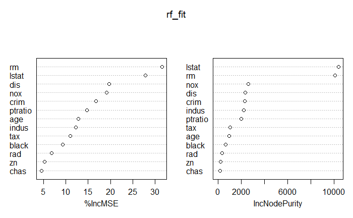

```r
# görselleştirildi
varImpPlot(rf_fit)
```

## Tahmin

```r
predict(rf_fit, test_x )
```

```
      12       14       20       22       26       28       31       40       45       46
20.70925 20.01312 19.57470 17.99513 16.11331 16.28843 14.56774 29.84395 22.29279 20.29780
      51       58       61       66       79      101      106      115      132      135
20.61630 32.11211 19.32952 26.20961 21.08309 23.14306 18.94383 20.88024 19.88860 16.14347
     138      141      143      148      154      157      158      160      165      168
18.43140 15.63154 16.74792 14.59831 16.77422 16.33511 33.34915 25.78649 20.33570 20.10167
     169      171      177      178      180      181      185      206      214      218
21.80377 19.68370 22.58787 24.89382 33.17640 38.99468 25.04751 21.94656 24.04143 23.40185
     220      222      223      225      226      227      237      240      243      245
22.19887 20.72073 26.30987 43.62425 41.02415 44.58348 26.66169 25.53357 21.70573 18.94283
     250      254      277      279      282      284      292      293      298      309
26.15709 37.45958 33.34467 25.26389 33.51378 44.39292 33.20115 27.93976 20.92803 27.91735
     314      315      321      322      328      335      336      337      341      348
21.63240 22.86893 23.77492 23.68117 21.01548 22.81968 20.77820 19.63359 20.21334 24.50361
     351      355      361      364      366      368      375      376      382      393
24.19116 20.47488 24.97766 19.19596 25.82660 20.32387 17.80799 22.06751 11.16935 10.55551
     394      407      414      433      441      443      450      455      456      457
14.05954 18.43183 15.27042 18.77980 10.13574 15.34323 14.84051 13.70441 16.05997 16.89106
     458      461      469      470      474      478      481      483      495
14.92298 17.51605 16.27139 17.73621 24.87841 14.23629 20.98692 28.89540 20.42029
```

## Model Tunning

```r
ctrl <- trainControl(method = "cv", number = 10)


ncol(train_x)/3

tune_grid <- expand.grid(mtry = c(2,3,4,5,10))
rf_tune <- train( train_x, train_y,
                  method = "rf",
                  tuneGrid = tune_grid,
                  trControl = ctrl

)

rf_tune
plot(rf_tune)

rf_tune$results %>% filter(mtry == as.numeric(rf_tune$bestTune))

defaultSummary(data.frame(obs = test_y,
                            pred = predict(rf_tune, test_x)))
```

## Caret ile Random Search

```r
ctrl <- trainControl(method = "cv",
                     number = 10,
                     search = "random")

rf_random_tune <- train( train_x, train_y,
                  method = "rf",
                  tuneLength = 5,
                  trControl = ctrl

)

rf_random_tune
```

## Caret ile Grid Search

```r
ctrl <- trainControl(method = "cv",
                     number = 10,
                     search = "grid")

tune_grid <- expand.grid(mtry = c(1:10))

rf_random_tune <- train(train_x, train_y,
                  method = "rf",
                  tuneGrid = tune_grid,
                  trControl = ctrl

)



model_listesi <- list()

for (ntree in c(100, 200, 300, 500, 1000, 2000)) {

  set.seed(123)

  fit <- train(train_x, train_y,
                  method = "rf",
                  tuneGrid = tune_grid,
                  trControl = ctrl,
                  ntree = ntree)

  key <- toString(ntree)
  model_listesi[[key]] <- fit

}

sonuclar <- resamples(model_listesi)
summary(sonuclar)
```

# GBM

## Model

```r
gbm_fit <- gbm(medv ~ ., data = training ,
    distribution = "gaussian",
    n.trees = 5000,
    interaction.depth = 1,
    shrinkage = 0.01,
    cv.folds = 5)

summary(gbm_fit)

names(gbm_fit)

gbm.perf(gbm_fit, method = "cv")



defaultSummary(data.frame(obs = train_y,
                            pred = gbm_fit$fit))
```

## Tahmin

```r
predict(gbm_fit, test_x, n.trees = 5000)


defaultSummary(data.frame(obs = test_y,
                            pred = predict(gbm_fit, test_x, n.trees = 1000)))


plot(predict(gbm_fit, test_x, n.trees = 5000), test_y,
     xlab = "Tahmin Edilen", ylab = "Gercek",
     main = "Tahmin Edilen vs Gercek: GBM",
     col = "dodgerblue", pch = 20)

grid()

abline(0, 1, col = "darkorange", lwd = 2)
```

## Model Tuning

```r
ctrl <- trainControl(method = "cv", 10,
                     search = "grid")


gbm_grid <- expand.grid(
            interaction.depth = seq(1, 7, by = 2),
            n.trees = seq(100, 1000, by = 50),
            shrinkage = c(0.01, 0.1),
            n.minobsinnode = c(10:20))


gbm_tune_fit <- train(train_x, train_y,
      method = "gbm",
      trControl = ctrl,
      tuneGrid = gbm_grid,
      verbose = FALSE
      )


plot(gbm_tune_fit)
gbm_tune_fit$finalModel

gbm_tune_fit$results %>%
  filter(n.trees == as.numeric(gbm_tune_fit$bestTune$n.trees) &
         interaction.depth == as.numeric(gbm_tune_fit$bestTune$interaction.depth) &
         shrinkage == as.numeric(gbm_tune_fit$bestTune$shrinkage) &
        n.minobsinnode == as.numeric(gbm_tune_fit$bestTune$n.minobsinnode))


defaultSummary(data.frame(obs = test_y,
                            pred = predict(gbm_tune_fit, test_x)))
```

# XGBoost

## Giris

Ozellikleri

Hiz: XGBoost OpenMD sayesinde otomatik olarak paralel hesaplama yapar. Boylece klasik GBM’den 10 kat daha hizli calisir.

Girdi Tipleri: Yogunluk matrisi - R’in yogunluk matrisi: matrix Seyrek matrisi - R’in seyreklik matrisi - Matrix::dgCMatrix Kendi veri sinifi: xgb.DMatrix

Seyreklik: Regresyon ya da siniflandirma problemleri icin seyrek girdileri kabul eder buna gore optimize edilmistir.

Ozellestirme: Objective fonksiyonlari ve evaluation fonksiyonlari ozellestirilebilir. Yani makine ogrenmesi problem turune gore olceklenebilir ve basari degerlendirme kriterleri de duzenlenebilir.

Kurulum

```r
#en guncel versiyon icin

install.packages("drat", repos="https://cran.rstudio.com")
drat:::addRepo("dmlc")
install.packages("xgboost", repos="http://dmlc.ml/drat/", type = "source")

#cran versiyonu icin
#install.packages("xgboost")
library(xgboost)
```

## Model

Model

```r
xgboost_fit <-xgboost(data = as.matrix(train_x),
        label = train_y,
        booster = "gblinear",
        max.depth = 2,
        eta = 1,
        nthread = 2,
        nrounds = 1000)


dtrain <- xgb.DMatrix(data = as.matrix(train_x), label = train_y)
dtest <- xgb.DMatrix(data = as.matrix(test_x), label = test_y)

xgboost_fit <-xgboost(data = dtrain,
        booster = "gblinear",
        max.depth = 2,
        eta = 1,
        nthread = 2,
        nrounds = 3)

xgboost_fit


class(dtrain)


imp_matris <- xgb.importance(model = xgboost_fit)
imp_matris

xgb.plot.importance(imp_matris)
```

Model Takip: watchlist

```r
watchlist <- list(train = dtrain, test = dtest)

xgb_fit <- xgb.train(data = dtrain,
                     booster = "gblinear",
                     max.depth = 4,
                     eta = 0.1,
                     nthread = 2,
                     nrounds = 100,
                     watchlist = watchlist)
```

## Tahmin

```r
predict(xgb_fit, as.matrix(test_x))

plot(predict(xgb_fit, as.matrix(test_x)), test_y,
     xlab = "Tahmin Edilen", ylab = "Gercek",
     main = "Tahmin Edilen vs Gercek: XGBoost",
     col = "dodgerblue", pch = 20)
grid()
abline(0, 1, col = "darkorange", lwd = 2)


defaultSummary(data.frame(obs = test_y,
                            pred = predict(xgb_fit, as.matrix(test_x))))
```

## Model Tuning

```r
ctrl <- trainControl(method = "cv", number = 10)

xgb_grid <- expand.grid(
  nrounds = 1000,
  lambda = c(1,2,3),
  alpha = c(0, 0.5, 1),
  eta = c(0, 0.5, 1)

)


xgb_tune_fit <- train(
  x = data.matrix(train_x),
  y = train_y,
  trControl = ctrl,
  tuneGrid = xgb_grid,
  method = "xgbLinear"
)

defaultSummary(data.frame(obs = test_y,
                            pred = predict(xgb_tune_fit, as.matrix(test_x))))
```

# Gelismis Hiperparametre Optimizasyonu

Bu bolum bir kac kaggle kerneli ve buraya kdarki tum deneyimlerimiz ile derlendi.

https://www.kaggle.com/pelkoja/visual-xgboost-tuning-with-caret

## Default Hiperparametreler

```r
grid_default <- expand.grid(
  nrounds = 100,
  max_depth = 6,
  eta = 0.3,
  gamma = 0,
  colsample_bytree = 1,
  min_child_weight = 1,
  subsample = 1
)

ctrl <- trainControl(
  method = "none",
  verboseIter = FALSE,
  allowParallel = TRUE

)

xgb_base <- train(
  x = as.matrix(train_x),
  y = train_y,
  trControl = ctrl,
  tuneGrid = grid_default,
  method = "xgbTree",
  verbose = TRUE

)

defaultSummary(data.frame(obs = test_y,
                            pred = predict(xgb_base, as.matrix(test_x))))
```

## Adim 1: Iterasyon Sayisi ve Learning Rate Belirlenmesi

```r
nrounds <- 1000

tune_grid <- expand.grid(
  nrounds = seq(from = 200, to = nrounds, by = 50),
  eta = c(0.025, 0.05, 0.1, 0.3),
  max_depth = c(2, 3, 4, 5, 6),
  gamma = 0,
  colsample_bytree = 1,
  min_child_weight = 1,
  subsample = 1
)

ctrl <- trainControl(
  method = "cv",
  number = 10,
  verboseIter = FALSE,
  allowParallel = TRUE
)


xgb_tune <- train(
  x = as.matrix(train_x),
  y = train_y,
  trControl = ctrl,
  tuneGrid = tune_grid,
  method = "xgbTree",
  verbose = TRUE
)


defaultSummary(data.frame(obs = test_y,
                            pred = predict(xgb_tune, as.matrix(test_x))))


tuneplot <- function(x, probs = .90) {
  ggplot(x) +
  coord_cartesian(ylim = c(quantile(x$results$RMSE, probs = probs), min(x$results$RMSE))) +
    theme_bw()
}


tuneplot(xgb_tune)

xgb_tune$bestTune
```

```r
tune_grid2 <- expand.grid(
  nrounds = seq(from = 50, to = nrounds, by = 50),
  eta = xgb_tune$bestTune$eta,
  max_depth = 4,
  gamma = 0,
  colsample_bytree = 1,
  min_child_weight = c(1, 2, 3),
  subsample = 1
)


xgb_tune2 <- train(
  x = as.matrix(train_x),
  y = train_y,
  trControl = ctrl,
  tuneGrid = tune_grid2,
  method = "xgbTree",
  verbose = TRUE
)


tuneplot(xgb_tune2)

xgb_tune2$bestTune

defaultSummary(data.frame(obs = test_y,
                            pred = predict(xgb_tune2, as.matrix(test_x))))
```

## Adim 3: Degisken ve Gozlem Orneklemesi

```r
tune_grid3 <- expand.grid(
  nrounds = seq(from = 50, to = nrounds, by = 50),
  eta = xgb_tune$bestTune$eta,
  max_depth = 4,
  gamma = 0,
  colsample_bytree = c(0.4, 0.6, 0.8, 1.0),
  min_child_weight = xgb_tune2$bestTune$min_child_weight,
  subsample = c(0.5, 0.75, 1.0)
)

xgb_tune3 <- train(
  x = as.matrix(train_x),
  y = train_y,
  trControl = ctrl,
  tuneGrid = tune_grid3,
  method = "xgbTree",
  verbose = TRUE
)


tuneplot(xgb_tune3)


xgb_tune3$bestTune
defaultSummary(data.frame(obs = test_y,
                            pred = predict(xgb_tune3, as.matrix(test_x))))
```

## Adim 4: Gamma

```r
tune_grid4 <- expand.grid(
  nrounds = seq(from = 50, to = nrounds, by = 50),
  eta = xgb_tune$bestTune$eta,
  max_depth = 5,
  gamma = c(0, 0.05, 0.1, 0.5, 0.7, 0.9, 1.0),
  colsample_bytree = xgb_tune3$bestTune$colsample_bytree,
  min_child_weight = xgb_tune2$bestTune$min_child_weight,
  subsample = xgb_tune3$bestTune$subsample
)

xgb_tune4 <- train(
  x = as.matrix(train_x),
  y = train_y,
  trControl = ctrl,
  tuneGrid = tune_grid4,
  method = "xgbTree",
  verbose = TRUE
)

tuneplot(xgb_tune4)
xgb_tune4$bestTune

defaultSummary(data.frame(obs = test_y,
                            pred = predict(xgb_tune4, as.matrix(test_x))))
```

## Adim 5: Learning Rate’in Indirgenmesi

```r
tune_grid5 <- expand.grid(
  nrounds = seq(from = 100, to = 1000, by = 50),
  eta = c(0.01, 0.015, 0.025, 0.05, 0.1),
  max_depth = xgb_tune2$bestTune$max_depth,
  gamma = xgb_tune4$bestTune$gamma,
  colsample_bytree = xgb_tune3$bestTune$colsample_bytree,
  min_child_weight = xgb_tune2$bestTune$min_child_weight,
  subsample = xgb_tune3$bestTune$subsample
)

xgb_tune5 <- train(
  x = as.matrix(train_x),
  y = train_y,
  trControl = ctrl,
  tuneGrid = tune_grid5,
  method = "xgbTree",
  verbose = TRUE
)

tuneplot(xgb_tune5)

xgb_tune5$bestTune
defaultSummary(data.frame(obs = test_y,
                            pred = predict(xgb_tune5, test_x)))
```

## Adim 6: Son Model

```r
final_grid <- expand.grid(
  nrounds = xgb_tune5$bestTune$nrounds,
  eta = xgb_tune5$bestTune$eta,
  max_depth = xgb_tune5$bestTune$max_depth,
  gamma = xgb_tune5$bestTune$gamma,
  colsample_bytree = xgb_tune5$bestTune$colsample_bytree,
  min_child_weight = xgb_tune5$bestTune$min_child_weight,
  subsample = xgb_tune5$bestTune$subsample
)


xgb_son_model <- train(
  x = as.matrix(train_x),
  y = train_y,
  trControl = ctrl,
  tuneGrid = final_grid,
  method = "xgbTree",
  verbose = TRUE
)


#test hatasi
defaultSummary(data.frame(obs = test_y,
                            pred = predict(xgb_son_model, as.matrix(test_x))))
```

## Adim 7: Model Kaydetmek ve Paylasmak

Model Nesnesinin Kaydedilmesi

```r
save(xgb_son_model, file = "xgb_son_model.rda")
rm(xgb_son_model)
load("xgb_son_model.rda")

predict(xgb_son_model, test_x)
```